# Capstone Group 2

07/04/2022

# Table 1

**Table 1. By GI Condition**

| **Characteristic** | **Overall**, N = 4,202<sup>1</sup> | **Chronic GI conditions** **No**, N = 4,012<sup>1</sup> | **Chronic GI conditions** **Yes**, N = 126<sup>1</sup> | **Chronic GI conditions** **Missing**, N = 64<sup>1</sup> | **p-value**<sup>2</sup> |  |
| --- | --- | --- | --- | --- | --- | --- |
| Sex |  |  |  |  |  | 0.002 |
| Male | 2,419 (58%) | 2,301 (57%) | 90 (71%) | 28 (44%) |  |  |
| Female | 1,783 (42%) | 1,711 (43%) | 36 (29%) | 36 (56%) |  |  |
| Race |  |  |  |  | 0.3 |  |
| White | 1,019 (24%) | 976 (24%) | 33 (26%) | 10 (40%) |  |  |
| Black | 465 (11%) | 442 (11%) | 21 (17%) | 2 (8.0%) |  |  |
| Asian | 743 (18%) | 721 (18%) | 20 (16%) | 2 (8.0%) |  |  |
| Hispanic | 1,334 (32%) | 1,293 (32%) | 36 (29%) | 5 (20%) |  |  |
| Other | 601 (14%) | 579 (14%) | 16 (13%) | 6 (24%) |  |  |
| Unknown |  |  |  |  |  |  |
| Age |  |  |  |  | 0.14 |  |
| 18 - 25 | 63 (1.5%) | 56 (1.4%) | 1 (0.8%) | 6 (9.4%) |  |  |
| 26 - 40 | 405 (9.6%) | 369 (9.2%) | 13 (10%) | 23 (36%) |  |  |
| 41 - 55 | 790 (19%) | 744 (19%) | 32 (25%) | 14 (22%) |  |  |
| 56 - 70 | 1,347 (32%) | 1,292 (32%) | 45 (36%) | 10 (16%) |  |  |
| 71 - 85 | 1,131 (27%) | 1,095 (27%) | 27 (21%) | 9 (14%) |  |  |
| 86+ | 466 (11%) | 456 (11%) | 8 (6.3%) | 2 (3.1%) |  |  |
| Obesity | 1,212 (33%) | 1,185 (33%) | 26 (24%) | 1 (20%) | 0.060 |  |
| Unknown |  |  |  |  |  |  |
| Active Cancer | 220 (5.3%) | 204 (5.1%) | 16 (13%) | 0 (NA%) | <0.001 |  |
| Cardio Comorbidity | 2,618 (63%) | 2,538 (63%) | 80 (63%) | 0 (NA%) | >0.9 |  |
| Covid GI symptoms | 1,444 (35%) | 1,394 (35%) | 50 (40%) | 0 (NA%) | 0.3 |  |
| Unknown |  |  |  |  |  |  |
| Life Threatening Complications | 1,981 (48%) | 1,915 (48%) | 66 (52%) | 0 (NA%) | 0.3 |  |
| Unknown |  |  |  |  |  |  |
| Intubation | 793 (19%) | 770 (19%) | 23 (18%) | 0 (NA%) | 0.8 |  |
| Unknown |  |  |  |  |  |  |
| Death | 925 (22%) | 890 (22%) | 30 (24%) | 5 (8.3%) | 0.7 |  |
| Unknown |  |  |  |  |  |  |
| wave |  |  |  |  | <0.001 |  |
| wave1 | 3,720 (89%) | 3,620 (90%) | 100 (79%) | 0 (0%) |  |  |
| wave2 | 482 (11%) | 392 (9.8%) | 26 (21%) | 64 (100%) |  |  |
| Septic Shock | 379 (9.2%) | 365 (9.1%) | 14 (11%) | 0 (NA%) | 0.4 |  |
| Unknown |  |  |  |  |  |  |
| Arrhythmias | 301 (7.3%) | 287 (7.2%) | 14 (11%) | 0 (NA%) | 0.094 |  |
| Unknown |  |  |  |  |  |  |
| Myocardial Infarction | 126 (3.1%) | 118 (2.9%) | 8 (6.3%) | 0 (NA%) | 0.056 |  |
| Unknown |  |  |  |  |  |  |
| Heart Failure | 144 (3.5%) | 138 (3.4%) | 6 (4.8%) | 0 (NA%) | 0.5 |  |
| Unknown |  |  |  |  |  |  |
| Renal Replacement | 366 (8.9%) | 349 (8.7%) | 17 (13%) | 0 (NA%) | 0.063 |  |
| Unknown |  |  |  |  |  |  |
| Venous Thrombus Embolism | 237 (5.7%) | 231 (5.8%) | 6 (4.8%) | 0 (NA%) | 0.6 |  |
| Unknown |  |  |  |  |  |  |

<sup>1</sup> n (%)  
<sup>2</sup> Pearson's Chi-squared test; Fisher's exact test

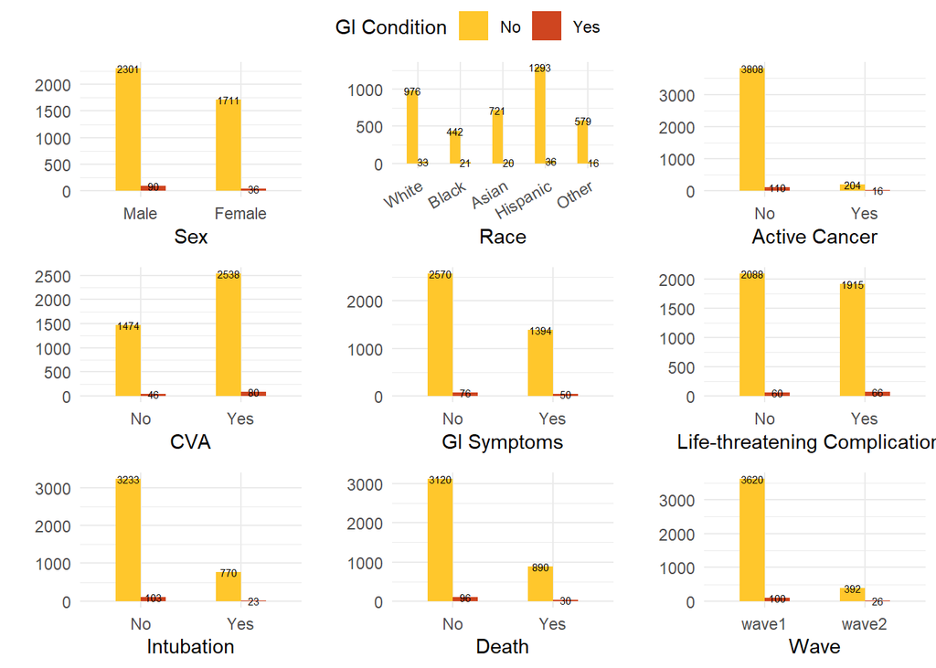

**Table 2. By GI Symptoms**

| **Characteristic** | **Overall**, N = 4,202<sup>1</sup> | **GI symptoms** **No**, N = 2,646<sup>1</sup> | **GI symptoms** **Yes**, N = 1,444<sup>1</sup> | **GI symptoms** **Missing**, N = 112<sup>1</sup> | **p-value**<sup>2</sup> |  |
| --- | --- | --- | --- | --- | --- | --- |
| Sex |  |  |  |  |  | <0.001 |
| Male | 2,419 (58%) | 1,591 (60%) | 783 (54%) | 45 (40%) |  |  |
| Female | 1,783 (42%) | 1,055 (40%) | 661 (46%) | 67 (60%) |  |  |
| Race |  |  |  |  | <0.001 |  |
| White | 1,019 (24%) | 671 (25%) | 324 (22%) | 24 (33%) |  |  |
| Black | 465 (11%) | 298 (11%) | 157 (11%) | 10 (14%) |  |  |
| Asian | 743 (18%) | 514 (19%) | 221 (15%) | 8 (11%) |  |  |
| Hispanic | 1,334 (32%) | 802 (30%) | 520 (36%) | 12 (17%) |  |  |
| Other | 601 (14%) | 361 (14%) | 222 (15%) | 18 (25%) |  |  |
| Unknown | 40 | 0 | 0 | 40 |  |  |
| Age |  |  |  |  | <0.001 |  |
| 18 - 25 | 63 (1.5%) | 27 (1.0%) | 23 (1.6%) | 13 (12%) |  |  |
| 26 - 40 | 405 (9.6%) | 201 (7.6%) | 167 (12%) | 37 (33%) |  |  |
| 41 - 55 | 790 (19%) | 455 (17%) | 318 (22%) | 17 (15%) |  |  |
| 56 - 70 | 1,347 (32%) | 817 (31%) | 510 (35%) | 20 (18%) |  |  |
| 71 - 85 | 1,131 (27%) | 774 (29%) | 336 (23%) | 21 (19%) |  |  |
| 86+ | 466 (11%) | 372 (14%) | 90 (6.2%) | 4 (3.6%) |  |  |
| Obesity | 1,212 (33%) | 715 (30%) | 486 (38%) | 11 (27%) | <0.001 |  |
| Unknown | 495 | 256 | 168 | 71 |  |  |
| Active Cancer | 220 (5.3%) | 142 (5.4%) | 72 (5.0%) | 6 (12%) | 0.6 |  |
| Unknown | 64 | 0 | 0 | 64 |  |  |
| Cardio Comorbidity | 2,618 (63%) | 1,757 (66%) | 842 (58%) | 19 (40%) | <0.001 |  |
| Unknown | 64 | 0 | 0 | 64 |  |  |
| Life Threatening Complications | 1,981 (48%) | 1,322 (50%) | 654 (45%) | 5 (12%) | 0.004 |  |
| Unknown | 73 | 4 | 0 | 69 |  |  |
| Intubation | 793 (19%) | 528 (20%) | 264 (18%) | 1 (2.4%) | 0.2 |  |
| Unknown | 73 | 3 | 0 | 70 |  |  |
| Death | 925 (22%) | 680 (26%) | 237 (16%) | 8 (7.5%) | <0.001 |  |
| Unknown | 6 | 0 | 0 | 6 |  |  |
| wave |  |  |  |  | 0.039 |  |
| wave1 | 3,720 (89%) | 2,416 (91%) | 1,290 (89%) | 14 (12%) |  |  |
| wave2 | 482 (11%) | 230 (8.7%) | 154 (11%) | 98 (88%) |  |  |

<sup>1</sup> n (%)  
<sup>2</sup> Pearson's Chi-squared test

**Table 1. Overall**

| **Characteristic** | **Overall**, N = 4,202<sup>1</sup> | **wave1**, N = 3,720<sup>1</sup> | **wave2**, N = 482<sup>1</sup> | **p-value**<sup>2</sup> |
| --- | --- | --- | --- | --- |
| Sex |  |  |  | <0.001 |
| Male | 2,419 (58%) | 2,189 (59%) | 230 (48%) |  |
| Female | 1,783 (42%) | 1,531 (41%) | 252 (52%) |  |
| Race |  |  |  | <0.001 |
| White | 1,019 (24%) | 869 (23%) | 150 (34%) |  |
| Black | 465 (11%) | 407 (11%) | 58 (13%) |  |
| Asian | 743 (18%) | 688 (18%) | 55 (12%) |  |
| Hispanic | 1,334 (32%) | 1,253 (34%) | 81 (18%) |  |
| Other | 601 (14%) | 503 (14%) | 98 (22%) |  |
| Unknown | 40 | 0 | 40 |  |
| Age |  |  |  | <0.001 |
| 18 - 25 | 63 (1.5%) | 45 (1.2%) | 18 (3.7%) |  |
| 26 - 40 | 405 (9.6%) | 336 (9.0%) | 69 (14%) |  |
| 41 - 55 | 790 (19%) | 701 (19%) | 89 (18%) |  |
| 56 - 70 | 1,347 (32%) | 1,222 (33%) | 125 (26%) |  |
| 71 - 85 | 1,131 (27%) | 992 (27%) | 139 (29%) |  |
| 86+ | 466 (11%) | 424 (11%) | 42 (8.7%) |  |
| Obesity | 1,212 (33%) | 1,157 (33%) | 55 (30%) | 0.4 |
| Unknown | 495 | 198 | 297 |  |
| Active Cancer | 220 (5.3%) | 168 (4.5%) | 52 (12%) | <0.001 |
| Unknown | 64 | 0 | 64 |  |
| Cardio Comorbidity | 2,618 (63%) | 2,353 (63%) | 265 (63%) | >0.9 |
| Unknown | 64 | 0 | 64 |  |
| Chronic GI Condition | 126 (3.0%) | 100 (2.7%) | 26 (6.2%) | <0.001 |
| Unknown | 64 | 0 | 64 |  |
| Covid GI symptoms | 1,444 (35%) | 1,290 (35%) | 154 (40%) | 0.039 |
| Unknown | 112 | 14 | 98 |  |
| Life Threatening Complications | 1,981 (48%) | 1,823 (49%) | 158 (39%) | <0.001 |
| Unknown | 73 | 1 | 72 |  |
| Intubation | 793 (19%) | 764 (21%) | 29 (7.1%) | <0.001 |
| Unknown | 73 | 0 | 73 |  |
| Death | 925 (22%) | 883 (24%) | 42 (8.8%) | <0.001 |
| Unknown | 6 | 0 | 6 |  |

<sup>1</sup> n (%)  
<sup>2</sup> Pearson's Chi-squared test

# Objective 1

**Determine if patients who were hospitalized with GI/Hepatic conditions during the first two waves of COVID 19 were more likely to report having GI symptoms.**

Primary exposure: Presence of chronic liver disease or chronic gastrointestinal conditions, including hepatitis B, hepatitis C, cirrhosis, liver transplants, or inflammatory bowel disease.

Primary outcome: COVID Symptoms, including abdominal pain, nausea or diarrhea.

## Logistic model

```
##
## Call:
## glm(formula = gi_symptoms ~ gi_condition + sex + race_eth + age_cat +
##     obesity + cancer_factor + cva_comorbidity + wave, family = "binomial",
##     data = wave_clean)
##
## Deviance Residuals:
##     Min       1Q   Median       3Q      Max
## -1.2674  -0.9587  -0.7989   1.3062   1.9950
##
## Coefficients:
##                     Estimate Std. Error z value Pr(>|z|)
## (Intercept)        -0.442439   0.322377  -1.372  0.16993
## gi_conditionYes     0.018320   0.209981   0.087  0.93047
## sexFemale           0.343106   0.072886   4.707 2.51e-06 ***
## race_ethBlack      -0.087048   0.132329  -0.658  0.51066
## race_ethAsian      -0.129494   0.116780  -1.109  0.26749
## race_ethHispanic    0.144650   0.098742   1.465  0.14294
## race_ethOther       0.145322   0.120491   1.206  0.22778
## age_cat26 - 40     -0.000219   0.331478  -0.001  0.99947
## age_cat41 - 55     -0.107648   0.322140  -0.334  0.73825
## age_cat56 - 70     -0.199776   0.320171  -0.624  0.53265
## age_cat71 - 85     -0.535994   0.324459  -1.652  0.09854 .
## age_cat86+         -1.114967   0.342560  -3.255  0.00113 **
## obesityYes          0.163368   0.078145   2.091  0.03657 *
## cancer_factorYes    0.026971   0.166130   0.162  0.87103
## cva_comorbidityYes -0.129808   0.081788  -1.587  0.11248
## wavewave2          -0.155818   0.179754  -0.867  0.38603
## ---
## Signif. codes:  0 '***' 0.001 '**' 0.01 '*' 0.05 '.' 0.1 ' ' 1
##
## (Dispersion parameter for binomial family taken to be 1)
##
##     Null deviance: 4738.2  on 3665  degrees of freedom
## Residual deviance: 4599.2  on 3650  degrees of freedom
##   (536 observations deleted due to missingness)
## AIC: 4631.2
##
## Number of Fisher Scoring iterations: 4
```

```
##                       OR 2.5 % 97.5 %
## (Intercept)        0.642 0.338  1.207
## gi_conditionYes    1.018 0.669  1.527
## sexFemale          1.409 1.222  1.626
## race_ethBlack      0.917 0.706  1.187
## race_ethAsian      0.879 0.698  1.104
## race_ethHispanic   1.156 0.953  1.403
## race_ethOther      1.156 0.913  1.464
## age_cat26 - 40     1.000 0.523  1.932
## age_cat41 - 55     0.898 0.478  1.705
## age_cat56 - 70     0.819 0.438  1.549
## age_cat71 - 85     0.585 0.310  1.116
## age_cat86+         0.328 0.168  0.647
## obesityYes         1.177 1.010  1.372
## cancer_factorYes   1.027 0.738  1.417
## cva_comorbidityYes 0.878 0.748  1.031
## wavewave2          0.856 0.597  1.211
```

Moreover, we found that patients who have obesity are more likely to have GI symptoms compared to patients who do not have obesity. Studies have shown that obesity is a risk factor of GI disease.

We also surprisingly found that elder people have a less possibility to have GI symptoms compared to youngsters. This could make sense because GI symptoms are milder than lung or other symptoms. Elder people might tend to have more severe symptoms instead of GI symptoms.

# Objective 2

**Determine if patients hospitalized with GI symptoms during the first two waves of COVID 19 had similar in-hospital outcomes to those who did not report such symptoms.**

Primary exposure: COVID Symptoms, including abdominal pain, nausea or diarrhea.

Primary outcome: in-hospital life threatening complications (Septic shock, positive blood culture, renal replacement therapy, arrhythmias, myocardial infarction, heart failure, venous thrombus embolism, coagulation), intubation, or death.

## Logistic model

```
##
## Call:
## glm(formula = outcome ~ gi_symptoms + sex + race_eth + age_cat +
##     obesity + cancer_factor + cva_comorbidity + wave, family = "binomial",
##     data = wave_clean)
##
## Deviance Residuals:
##     Min       1Q   Median       3Q      Max
## -2.0496  -1.1396   0.7368   0.9841   2.0135
##
## Coefficients:
##                     Estimate Std. Error z value Pr(>|z|)
## (Intercept)        -1.109113   0.376228  -2.948  0.00320 **
## gi_symptomsYes     -0.149263   0.074078  -2.015  0.04391 *
## sexFemale          -0.443228   0.072987  -6.073 1.26e-09 ***
## race_ethBlack       0.199063   0.130833   1.522  0.12813
## race_ethAsian       0.221106   0.113488   1.948  0.05138 .
## race_ethHispanic    0.036435   0.097994   0.372  0.71003
## race_ethOther      -0.004823   0.119468  -0.040  0.96780
## age_cat26 - 40      0.399839   0.384937   1.039  0.29894
## age_cat41 - 55      0.689698   0.374861   1.840  0.06579 .
## age_cat56 - 70      1.101007   0.372760   2.954  0.00314 **
## age_cat71 - 85      1.545970   0.376339   4.108 3.99e-05 ***
## age_cat86+          2.005650   0.389628   5.148 2.64e-07 ***
## obesityYes          0.166014   0.078917   2.104  0.03541 *
## cancer_factorYes    0.366773   0.169547   2.163  0.03052 *
## cva_comorbidityYes  0.507390   0.080020   6.341 2.29e-10 ***
## wavewave2          -0.386646   0.174457  -2.216  0.02667 *
## ---
## Signif. codes:  0 '***' 0.001 '**' 0.01 '*' 0.05 '.' 0.1 ' ' 1
##
## (Dispersion parameter for binomial family taken to be 1)
##
##     Null deviance: 5016.2  on 3662  degrees of freedom
## Residual deviance: 4661.3  on 3647  degrees of freedom
##   (539 observations deleted due to missingness)
## AIC: 4693.3
##
## Number of Fisher Scoring iterations: 4
```

```
##
## Call:
## glm(formula = death ~ gi_symptoms + sex + race_eth + age_cat +
##     obesity + cancer_factor + cva_comorbidity + wave, family = "binomial",
##     data = wave_clean)
##
## Deviance Residuals:
##     Min       1Q   Median       3Q      Max
## -1.4479  -0.7610  -0.5207  -0.2464   2.7157
##
## Coefficients:
##                    Estimate Std. Error z value Pr(>|z|)
## (Intercept)        -3.65682    1.01933  -3.587 0.000334 ***
## gi_symptomsYes     -0.26642    0.09360  -2.846 0.004421 **
## sexFemale          -0.41537    0.08851  -4.693  2.7e-06 ***
## race_ethBlack      -0.03198    0.15641  -0.204 0.838008
## race_ethAsian       0.35186    0.12547   2.804 0.005042 **
## race_ethHispanic    0.21601    0.11584   1.865 0.062228 .
## race_ethOther      -0.11968    0.14874  -0.805 0.421051
## age_cat26 - 40      0.59257    1.04818   0.565 0.571849
## age_cat41 - 55      1.31711    1.02279   1.288 0.197829
## age_cat56 - 70      2.16306    1.01797   2.125 0.033597 *
## age_cat71 - 85      2.86282    1.01888   2.810 0.004958 **
## age_cat86+          3.58476    1.02283   3.505 0.000457 ***
## obesityYes          0.24062    0.09806   2.454 0.014140 *
## cancer_factorYes    0.27841    0.17538   1.587 0.112402
## cva_comorbidityYes  0.19409    0.10296   1.885 0.059417 .
## wavewave2          -1.05655    0.28471  -3.711 0.000207 ***
## ---
## Signif. codes:  0 '***' 0.001 '**' 0.01 '*' 0.05 '.' 0.1 ' ' 1
##
## (Dispersion parameter for binomial family taken to be 1)
##
##     Null deviance: 3943.8  on 3665  degrees of freedom
## Residual deviance: 3501.7  on 3650  degrees of freedom
##   (536 observations deleted due to missingness)
## AIC: 3533.7
##
## Number of Fisher Scoring iterations: 6
```

```
##
## Call:
## glm(formula = intubation1 ~ gi_symptoms + sex + race_eth + age_cat +
##     obesity + cancer_factor + cva_comorbidity + wave, family = "binomial",
##     data = wave_clean)
##
## Deviance Residuals:
##     Min       1Q   Median       3Q      Max
## -1.0982  -0.7469  -0.6049  -0.3323   2.8593
##
## Coefficients:
##                    Estimate Std. Error z value Pr(>|z|)
## (Intercept)        -1.94025    0.49281  -3.937 8.25e-05 ***
## gi_symptomsYes     -0.12358    0.08969  -1.378   0.1683
## sexFemale          -0.47326    0.08968  -5.277 1.31e-07 ***
## race_ethBlack      -0.24379    0.16510  -1.477   0.1398
## race_ethAsian       0.31932    0.13209   2.418   0.0156 *
## race_ethHispanic    0.07603    0.11767   0.646   0.5182
## race_ethOther       0.02395    0.14521   0.165   0.8690
## age_cat26 - 40     -0.05112    0.51075  -0.100   0.9203
## age_cat41 - 55      0.56694    0.49181   1.153   0.2490
## age_cat56 - 70      0.95360    0.48881   1.951   0.0511 .
## age_cat71 - 85      0.71708    0.49305   1.454   0.1458
## age_cat86+         -0.37527    0.52215  -0.719   0.4723
## obesityYes          0.43475    0.09222   4.714 2.43e-06 ***
## cancer_factorYes   -0.22445    0.21347  -1.051   0.2930
## cva_comorbidityYes  0.04338    0.09670   0.449   0.6537
## wavewave2          -1.79876    0.42140  -4.269 1.97e-05 ***
## ---
## Signif. codes:  0 '***' 0.001 '**' 0.01 '*' 0.05 '.' 0.1 ' ' 1
##
## (Dispersion parameter for binomial family taken to be 1)
##
##     Null deviance: 3735.7  on 3663  degrees of freedom
## Residual deviance: 3540.5  on 3648  degrees of freedom
##   (538 observations deleted due to missingness)
## AIC: 3572.5
##
## Number of Fisher Scoring iterations: 5
```

```
##
## Call:
## glm(formula = comp_factor ~ gi_symptoms + sex + race_eth + age_cat +
##     obesity + cancer_factor + cva_comorbidity + wave, family = "binomial",
##     data = wave_clean)
##
## Deviance Residuals:
##     Min       1Q   Median       3Q      Max
## -1.6865  -1.1488   0.7828   1.0839   1.9099
##
## Coefficients:
##                      Estimate Std. Error z value Pr(>|z|)
## (Intercept)        -1.2141296  0.3879787  -3.129 0.001752 **
## gi_symptomsYes     -0.0411025  0.0729876  -0.563 0.573337
## sexFemale          -0.4337954  0.0712492  -6.088 1.14e-09 ***
## race_ethBlack       0.1796727  0.1266911   1.418 0.156134
## race_ethAsian       0.1039846  0.1088397   0.955 0.339380
## race_ethHispanic   -0.0742478  0.0954985  -0.777 0.436878
## race_ethOther       0.0003982  0.1167093   0.003 0.997278
## age_cat26 - 40      0.4078178  0.3978161   1.025 0.305296
## age_cat41 - 55      0.6713005  0.3874483   1.733 0.083163 .
## age_cat56 - 70      1.0847920  0.3851252   2.817 0.004852 **
## age_cat71 - 85      1.3140494  0.3880830   3.386 0.000709 ***
## age_cat86+          1.4170226  0.3977327   3.563 0.000367 ***
## obesityYes          0.1066064  0.0774855   1.376 0.168877
## cancer_factorYes    0.2649723  0.1591887   1.665 0.096009 .
## cva_comorbidityYes  0.4950130  0.0794852   6.228 4.73e-10 ***
## wavewave2          -0.2377061  0.1721649  -1.381 0.167375
## ---
## Signif. codes:  0 '***' 0.001 '**' 0.01 '*' 0.05 '.' 0.1 ' ' 1
##
## (Dispersion parameter for binomial family taken to be 1)
##
##     Null deviance: 5078.0  on 3662  degrees of freedom
## Residual deviance: 4838.4  on 3647  degrees of freedom
##   (539 observations deleted due to missingness)
## AIC: 4870.4
##
## Number of Fisher Scoring iterations: 4
```

```
##                       OR 2.5 % 97.5 %
## (Intercept)        0.330 0.150  0.666
## gi_symptomsYes     0.861 0.745  0.996
## sexFemale          0.642 0.556  0.740
## race_ethBlack      1.220 0.945  1.579
## race_ethAsian      1.247 0.999  1.559
## race_ethHispanic   1.037 0.856  1.257
## race_ethOther      0.995 0.788  1.258
## age_cat26 - 40     1.492 0.724  3.324
## age_cat41 - 55     1.993 0.989  4.366
## age_cat56 - 70     3.007 1.499  6.564
## age_cat71 - 85     4.693 2.321 10.306
## age_cat86+         7.431 3.575 16.704
## obesityYes         1.181 1.012  1.379
## cancer_factorYes   1.443 1.040  2.023
## cva_comorbidityYes 1.661 1.420  1.943
## wavewave2          0.679 0.482  0.956
```

```
##                        OR 2.5 %  97.5 %
## (Intercept)         0.026 0.001   0.121
## gi_symptomsYes      0.766 0.637   0.919
## sexFemale           0.660 0.554   0.785
## race_ethBlack       0.969 0.711   1.312
## race_ethAsian       1.422 1.112   1.818
## race_ethHispanic    1.241 0.990   1.559
## race_ethOther       0.887 0.661   1.185
## age_cat26 - 40      1.809 0.350  33.197
## age_cat41 - 55      3.733 0.785  66.886
## age_cat56 - 70      8.698 1.859 155.142
## age_cat71 - 85     17.511 3.733 312.614
## age_cat86+         36.045 7.587 645.943
## obesityYes          1.272 1.049   1.541
## cancer_factorYes    1.321 0.932   1.855
## cva_comorbidityYes  1.214 0.993   1.488
## wavewave2           0.348 0.191   0.589
```

```
##                       OR 2.5 % 97.5 %
## (Intercept)        0.144 0.048  0.346
## gi_symptomsYes     0.884 0.741  1.053
## sexFemale          0.623 0.522  0.742
## race_ethBlack      0.784 0.564  1.079
## race_ethAsian      1.376 1.062  1.783
## race_ethHispanic   1.079 0.857  1.360
## race_ethOther      1.024 0.769  1.360
## age_cat26 - 40     0.950 0.377  2.908
## age_cat41 - 55     1.763 0.733  5.244
## age_cat56 - 70     2.595 1.086  7.685
## age_cat71 - 85     2.048 0.849  6.106
## age_cat86+         0.687 0.266  2.140
## obesityYes         1.545 1.289  1.850
## cancer_factorYes   0.799 0.517  1.197
## cva_comorbidityYes 1.044 0.865  1.263
## wavewave2          0.166 0.064  0.347
```

## Death Survival

```
## Call:
## survdiff(formula = Surv(censer_death, as.numeric(death)) ~ gi_symptoms,
##     data = wave_clean)
##
## n=4090, 112 observations deleted due to missingness.
##
##                    N Observed Expected (O-E)^2/E (O-E)^2/V
## gi_symptoms=No  2646      680      604      9.68      28.9
## gi_symptoms=Yes 1444      237      313     18.64      28.9
##
##  Chisq= 28.9  on 1 degrees of freedom, p= 8e-08
```

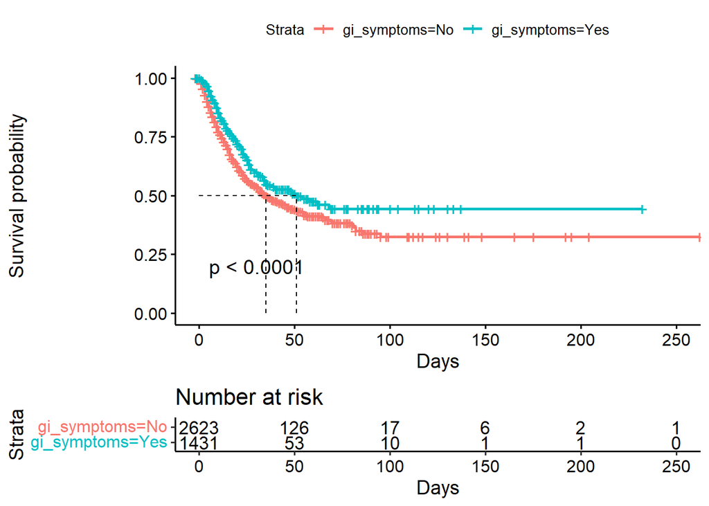

```
## Call: survfit(formula = Surv(censer_death, as.numeric(death)) ~ gi_symptoms,
##     data = wave_clean)
##
##    112 observations deleted due to missingness
##                    n events median 0.95LCL 0.95UCL
## gi_symptoms=No  2646    680     35      32      45
## gi_symptoms=Yes 1444    237     51      35      NA
```

**Interpret**: The effect of GI symptoms on survival time was investigated using survival analysis. Patients with GI symptoms had a median survival time of 51 days, whereas those without GI symptoms had a median survival time of 35 days. There was a significant difference between the two survival plots (p < 0.001). One possible explanation for this outcome is that GI symptoms may be minor in COVID-19 patients. Some of the more significant symptoms, such as lung symptoms, may be linked to death.

## specific complications

```
##
## Call:
## glm(formula = septic_shock ~ gi_symptoms + sex + race_eth + age_cat +
##     obesity + cancer_factor + cva_comorbidity + wave, family = binomial,
##     data = wave_clean)
##
## Deviance Residuals:
##     Min       1Q   Median       3Q      Max
## -0.6933  -0.5007  -0.4334  -0.3521   2.8681
##
## Coefficients:
##                    Estimate Std. Error z value Pr(>|z|)
## (Intercept)        -2.39503    0.61628  -3.886 0.000102 ***
## gi_symptomsYes     -0.20773    0.12353  -1.682 0.092639 .
## sexFemale          -0.28543    0.11905  -2.398 0.016502 *
## race_ethBlack      -0.18558    0.21355  -0.869 0.384824
## race_ethAsian       0.22820    0.16876   1.352 0.176292
## race_ethHispanic   -0.09074    0.15576  -0.583 0.560205
## race_ethOther      -0.18961    0.19825  -0.956 0.338859
## age_cat26 - 40     -0.60912    0.66126  -0.921 0.356966
## age_cat41 - 55      0.06131    0.61862   0.099 0.921053
## age_cat56 - 70      0.48828    0.61186   0.798 0.424852
## age_cat71 - 85      0.41055    0.61722   0.665 0.505951
## age_cat86+         -0.01964    0.64045  -0.031 0.975542
## obesityYes          0.31103    0.12530   2.482 0.013053 *
## cancer_factorYes    0.25864    0.23918   1.081 0.279534
## cva_comorbidityYes  0.03405    0.13171   0.258 0.796029
## wavewave2          -1.12647    0.46087  -2.444 0.014516 *
## ---
## Signif. codes:  0 '***' 0.001 '**' 0.01 '*' 0.05 '.' 0.1 ' ' 1
##
## (Dispersion parameter for binomial family taken to be 1)
##
##     Null deviance: 2344.9  on 3662  degrees of freedom
## Residual deviance: 2287.1  on 3647  degrees of freedom
##   (539 observations deleted due to missingness)
## AIC: 2319.1
##
## Number of Fisher Scoring iterations: 6
```

```
##
## Call:
## glm(formula = arrhythmias ~ gi_symptoms + sex + race_eth + age_cat +
##     obesity + cancer_factor + cva_comorbidity + wave, family = binomial,
##     data = wave_clean)
##
## Deviance Residuals:
##     Min       1Q   Median       3Q      Max
## -0.7166  -0.4693  -0.3671  -0.2366   3.0864
##
## Coefficients:
##                    Estimate Std. Error z value Pr(>|z|)
## (Intercept)        -3.51586    1.02558  -3.428 0.000608 ***
## gi_symptomsYes      0.01444    0.13726   0.105 0.916187
## sexFemale          -0.57091    0.13743  -4.154 3.27e-05 ***
## race_ethBlack      -0.18419    0.23489  -0.784 0.432944
## race_ethAsian       0.23085    0.18135   1.273 0.203024
## race_ethHispanic   -0.38578    0.18181  -2.122 0.033844 *
## race_ethOther       0.15629    0.20031   0.780 0.435233
## age_cat26 - 40     -0.54632    1.11085  -0.492 0.622860
## age_cat41 - 55      0.20380    1.03803   0.196 0.844347
## age_cat56 - 70      1.23807    1.02317   1.210 0.226264
## age_cat71 - 85      1.51539    1.02586   1.477 0.139626
## age_cat86+          1.15431    1.03988   1.110 0.266982
## obesityYes          0.34385    0.14317   2.402 0.016317 *
## cancer_factorYes   -0.24237    0.29978  -0.808 0.418811
## cva_comorbidityYes  0.19715    0.15512   1.271 0.203743
## wavewave2          -1.10992    0.51509  -2.155 0.031178 *
## ---
## Signif. codes:  0 '***' 0.001 '**' 0.01 '*' 0.05 '.' 0.1 ' ' 1
##
## (Dispersion parameter for binomial family taken to be 1)
##
##     Null deviance: 1997.8  on 3662  degrees of freedom
## Residual deviance: 1882.0  on 3647  degrees of freedom
##   (539 observations deleted due to missingness)
## AIC: 1914
##
## Number of Fisher Scoring iterations: 6
```

```
##
## Call:
## glm(formula = mi ~ gi_symptoms + sex + race_eth + age_cat + obesity +
##     cancer_factor + cva_comorbidity + wave, family = binomial,
##     data = wave_clean)
##
## Deviance Residuals:
##     Min       1Q   Median       3Q      Max
## -0.4427  -0.2923  -0.2272  -0.1692   3.4159
##
## Coefficients:
##                    Estimate Std. Error z value Pr(>|z|)
## (Intercept)        -16.3764   364.0834  -0.045  0.96412
## gi_symptomsYes      -0.2092     0.2214  -0.945  0.34459
## sexFemale           -0.7815     0.2216  -3.527  0.00042 ***
## race_ethBlack        0.2050     0.3417   0.600  0.54860
## race_ethAsian        0.2607     0.2862   0.911  0.36232
## race_ethHispanic    -0.1179     0.2838  -0.416  0.67773
## race_ethOther        0.2697     0.3148   0.856  0.39173
## age_cat26 - 40      11.3050   364.0841   0.031  0.97523
## age_cat41 - 55      12.4240   364.0835   0.034  0.97278
## age_cat56 - 70      12.6522   364.0834   0.035  0.97228
## age_cat71 - 85      13.0004   364.0834   0.036  0.97152
## age_cat86+          13.0126   364.0835   0.036  0.97149
## obesityYes           0.2333     0.2214   1.054  0.29190
## cancer_factorYes    -0.2213     0.4690  -0.472  0.63706
## cva_comorbidityYes   0.5871     0.2612   2.247  0.02461 *
## wavewave2           -0.8754     0.7230  -1.211  0.22594
## ---
## Signif. codes:  0 '***' 0.001 '**' 0.01 '*' 0.05 '.' 0.1 ' ' 1
##
## (Dispersion parameter for binomial family taken to be 1)
##
##     Null deviance: 1008.65  on 3662  degrees of freedom
## Residual deviance:  961.14  on 3647  degrees of freedom
##   (539 observations deleted due to missingness)
## AIC: 993.14
##
## Number of Fisher Scoring iterations: 15
```

```
##
## Call:
## glm(formula = hf1 ~ gi_symptoms + sex + race_eth + age_cat +
##     obesity + cancer_factor + cva_comorbidity + wave, family = binomial,
##     data = wave_clean)
##
## Deviance Residuals:
##     Min       1Q   Median       3Q      Max
## -0.5689  -0.3004  -0.2721  -0.2044   3.0120
##
## Coefficients:
##                     Estimate Std. Error z value Pr(>|z|)
## (Intercept)        -2.874912   0.758210  -3.792  0.00015 ***
## gi_symptomsYes      0.003211   0.191517   0.017  0.98662
## sexFemale          -0.088114   0.183880  -0.479  0.63180
## race_ethBlack      -0.117384   0.302539  -0.388  0.69802
## race_ethAsian      -0.381745   0.280793  -1.360  0.17398
## race_ethHispanic   -0.303297   0.242475  -1.251  0.21099
## race_ethOther      -0.179980   0.289529  -0.622  0.53418
## age_cat26 - 40     -1.167353   0.856127  -1.364  0.17272
## age_cat41 - 55     -0.714928   0.765915  -0.933  0.35060
## age_cat56 - 70     -0.641353   0.753968  -0.851  0.39497
## age_cat71 - 85     -0.661478   0.761478  -0.869  0.38502
## age_cat86+         -0.611878   0.786205  -0.778  0.43641
## obesityYes         -0.183066   0.206743  -0.885  0.37590
## cancer_factorYes    0.703921   0.299681   2.349  0.01883 *
## cva_comorbidityYes  0.679197   0.235501   2.884  0.00393 **
## wavewave2           0.507926   0.346153   1.467  0.14228
## ---
## Signif. codes:  0 '***' 0.001 '**' 0.01 '*' 0.05 '.' 0.1 ' ' 1
##
## (Dispersion parameter for binomial family taken to be 1)
##
##     Null deviance: 1149.6  on 3662  degrees of freedom
## Residual deviance: 1120.9  on 3647  degrees of freedom
##   (539 observations deleted due to missingness)
## AIC: 1152.9
##
## Number of Fisher Scoring iterations: 6
```

```
##
## Call:
## glm(formula = vte1 ~ gi_symptoms + sex + race_eth + age_cat +
##     obesity + cancer_factor + cva_comorbidity + wave, family = binomial,
##     data = wave_clean)
##
## Deviance Residuals:
##     Min       1Q   Median       3Q      Max
## -0.7271  -0.3978  -0.3282  -0.2602   2.9675
##
## Coefficients:
##                    Estimate Std. Error z value Pr(>|z|)
## (Intercept)         -3.4661     1.0268  -3.376 0.000736 ***
## gi_symptomsYes      -0.2418     0.1551  -1.559 0.118959
## sexFemale           -0.3764     0.1501  -2.508 0.012136 *
## race_ethBlack        0.5740     0.2223   2.582 0.009811 **
## race_ethAsian       -0.1332     0.2291  -0.581 0.560980
## race_ethHispanic    -0.2026     0.2004  -1.011 0.311987
## race_ethOther        0.1025     0.2302   0.445 0.656152
## age_cat26 - 40      -0.3456     1.0948  -0.316 0.752218
## age_cat41 - 55       0.5865     1.0320   0.568 0.569803
## age_cat56 - 70       1.2708     1.0230   1.242 0.214162
## age_cat71 - 85       1.1841     1.0280   1.152 0.249390
## age_cat86+           0.5015     1.0576   0.474 0.635332
## obesityYes           0.1745     0.1551   1.125 0.260445
## cancer_factorYes     0.5065     0.2601   1.947 0.051482 .
## cva_comorbidityYes  -0.1684     0.1608  -1.047 0.295010
## wavewave2           -0.2356     0.3766  -0.626 0.531568
## ---
## Signif. codes:  0 '***' 0.001 '**' 0.01 '*' 0.05 '.' 0.1 ' ' 1
##
## (Dispersion parameter for binomial family taken to be 1)
##
##     Null deviance: 1680.6  on 3663  degrees of freedom
## Residual deviance: 1616.9  on 3648  degrees of freedom
##   (538 observations deleted due to missingness)
## AIC: 1648.9
##
## Number of Fisher Scoring iterations: 6
```

```
##
## Call:
## glm(formula = renal_replacement1 ~ gi_symptoms + sex + race_eth +
##     age_cat + obesity + cancer_factor + cva_comorbidity + wave,
##     family = binomial, data = wave_clean)
##
## Deviance Residuals:
##     Min       1Q   Median       3Q      Max
## -0.8769  -0.5147  -0.3803  -0.2625   2.9153
##
## Coefficients:
##                     Estimate Std. Error z value Pr(>|z|)
## (Intercept)        -17.00310  359.38098  -0.047 0.962264
## gi_symptomsYes      -0.18354    0.12543  -1.463 0.143399
## sexFemale           -0.54907    0.12554  -4.374 1.22e-05 ***
## race_ethBlack        0.78023    0.20310   3.842 0.000122 ***
## race_ethAsian        0.62415    0.19137   3.262 0.001108 **
## race_ethHispanic     0.55693    0.17266   3.226 0.001257 **
## race_ethOther       -0.05288    0.22946  -0.230 0.817741
## age_cat26 - 40      13.03268  359.38107   0.036 0.971072
## age_cat41 - 55      13.81069  359.38096   0.038 0.969346
## age_cat56 - 70      14.28030  359.38095   0.040 0.968304
## age_cat71 - 85      13.86981  359.38096   0.039 0.969214
## age_cat86+          12.95140  359.38105   0.036 0.971252
## obesityYes           0.30813    0.12572   2.451 0.014248 *
## cancer_factorYes    -0.17317    0.29179  -0.593 0.552861
## cva_comorbidityYes   0.87683    0.15167   5.781 7.41e-09 ***
## wavewave2           -0.36456    0.34056  -1.070 0.284411
## ---
## Signif. codes:  0 '***' 0.001 '**' 0.01 '*' 0.05 '.' 0.1 ' ' 1
##
## (Dispersion parameter for binomial family taken to be 1)
##
##     Null deviance: 2327.0  on 3662  degrees of freedom
## Residual deviance: 2155.3  on 3647  degrees of freedom
##   (539 observations deleted due to missingness)
## AIC: 2187.3
##
## Number of Fisher Scoring iterations: 15
```

# Objective 3

**Determine in-hospital complications, including mortality among those with GI/Hepatic comorbidities of Covid 19 hospitalizations in a large hospital in NYC**

Primary exposure: Presence of chronic liver disease or chronic gastrointestinal conditions, including hepatitis B, hepatitis C, cirrhosis, liver transplants, or inflammatory bowel disease

Primary outcome: in-hospital life threatening complications (Septic shock, positive blood culture, renal replacement therapy, arrhythmias, myocardial infarction, heart failure, venous thrombus embolism, coagulation), intubation, or death.

## Life threatening complications

## Logistic model

```
##
## Call:
## glm(formula = outcome ~ gi_condition + sex + race_eth + age_cat +
##     obesity + cancer_factor + cva_comorbidity + wave, family = binomial,
##     data = wave_clean)
##
## Deviance Residuals:
##     Min       1Q   Median       3Q      Max
## -2.0358  -1.1439   0.7458   0.9985   2.0768
##
## Coefficients:
##                    Estimate Std. Error z value Pr(>|z|)
## (Intercept)        -1.30130    0.36883  -3.528 0.000418 ***
## gi_conditionYes     0.22915    0.21129   1.085 0.278142
## sexFemale          -0.44733    0.07257  -6.164 7.10e-10 ***
## race_ethBlack       0.20532    0.13010   1.578 0.114522
## race_ethAsian       0.22500    0.11299   1.991 0.046436 *
## race_ethHispanic    0.04441    0.09767   0.455 0.649299
## race_ethOther      -0.01200    0.11866  -0.101 0.919441
## age_cat26 - 40      0.47821    0.37814   1.265 0.206001
## age_cat41 - 55      0.81300    0.36835   2.207 0.027305 *
## age_cat56 - 70      1.22197    0.36624   3.337 0.000848 ***
## age_cat71 - 85      1.67728    0.36980   4.536 5.74e-06 ***
## age_cat86+          2.16478    0.38310   5.651 1.60e-08 ***
## obesityYes          0.16675    0.07878   2.117 0.034296 *
## cancer_factorYes    0.35285    0.16768   2.104 0.035349 *
## cva_comorbidityYes  0.51595    0.07981   6.465 1.01e-10 ***
## wavewave2          -0.49613    0.16621  -2.985 0.002836 **
## ---
## Signif. codes:  0 '***' 0.001 '**' 0.01 '*' 0.05 '.' 0.1 ' ' 1
##
## (Dispersion parameter for binomial family taken to be 1)
##
##     Null deviance: 5070.0  on 3696  degrees of freedom
## Residual deviance: 4695.8  on 3681  degrees of freedom
##   (505 observations deleted due to missingness)
## AIC: 4727.8
##
## Number of Fisher Scoring iterations: 4
```

```
##
## Call:
## glm(formula = death ~ gi_condition + sex + race_eth + age_cat +
##     obesity + cancer_factor + cva_comorbidity + wave, family = binomial,
##     data = wave_clean)
##
## Deviance Residuals:
##     Min       1Q   Median       3Q      Max
## -1.4866  -0.7450  -0.5041  -0.2291   2.7876
##
## Coefficients:
##                    Estimate Std. Error z value Pr(>|z|)
## (Intercept)        -3.83942    1.01728  -3.774 0.000161 ***
## gi_conditionYes     0.38383    0.23928   1.604 0.108682
## sexFemale          -0.43194    0.08820  -4.897 9.72e-07 ***
## race_ethBlack      -0.03563    0.15605  -0.228 0.819400
## race_ethAsian       0.36023    0.12520   2.877 0.004011 **
## race_ethHispanic    0.20709    0.11562   1.791 0.073274 .
## race_ethOther      -0.12577    0.14843  -0.847 0.396793
## age_cat26 - 40      0.64071    1.04657   0.612 0.540408
## age_cat41 - 55      1.38703    1.02131   1.358 0.174435
## age_cat56 - 70      2.24038    1.01646   2.204 0.027517 *
## age_cat71 - 85      2.96746    1.01730   2.917 0.003534 **
## age_cat86+          3.72020    1.02112   3.643 0.000269 ***
## obesityYes          0.23846    0.09800   2.433 0.014963 *
## cancer_factorYes    0.26128    0.17515   1.492 0.135769
## cva_comorbidityYes  0.19955    0.10278   1.941 0.052202 .
## wavewave2          -1.13281    0.28293  -4.004 6.23e-05 ***
## ---
## Signif. codes:  0 '***' 0.001 '**' 0.01 '*' 0.05 '.' 0.1 ' ' 1
##
## (Dispersion parameter for binomial family taken to be 1)
##
##     Null deviance: 3963.9  on 3699  degrees of freedom
## Residual deviance: 3514.0  on 3684  degrees of freedom
##   (502 observations deleted due to missingness)
## AIC: 3546
##
## Number of Fisher Scoring iterations: 6
```

```
##
## Call:
## glm(formula = intubation1 ~ gi_condition + sex + race_eth + age_cat +
##     obesity + cancer_factor + cva_comorbidity + wave, family = binomial,
##     data = wave_clean)
##
## Deviance Residuals:
##     Min       1Q   Median       3Q      Max
## -1.0836  -0.7450  -0.6000  -0.3322   2.8446
##
## Coefficients:
##                    Estimate Std. Error z value Pr(>|z|)
## (Intercept)        -2.09041    0.48820  -4.282 1.85e-05 ***
## gi_conditionYes    -0.09370    0.25501  -0.367   0.7133
## sexFemale          -0.48328    0.08935  -5.409 6.35e-08 ***
## race_ethBlack      -0.22008    0.16424  -1.340   0.1803
## race_ethAsian       0.32881    0.13191   2.493   0.0127 *
## race_ethHispanic    0.07924    0.11749   0.674   0.5000
## race_ethOther       0.01825    0.14499   0.126   0.8998
## age_cat26 - 40      0.02897    0.50688   0.057   0.9544
## age_cat41 - 55      0.66644    0.48805   1.366   0.1721
## age_cat56 - 70      1.05788    0.48506   2.181   0.0292 *
## age_cat71 - 85      0.82074    0.48929   1.677   0.0935 .
## age_cat86+         -0.25227    0.51835  -0.487   0.6265
## obesityYes          0.42860    0.09210   4.654 3.26e-06 ***
## cancer_factorYes   -0.18331    0.21080  -0.870   0.3845
## cva_comorbidityYes  0.05039    0.09661   0.522   0.6019
## wavewave2          -1.73586    0.39094  -4.440 8.99e-06 ***
## ---
## Signif. codes:  0 '***' 0.001 '**' 0.01 '*' 0.05 '.' 0.1 ' ' 1
##
## (Dispersion parameter for binomial family taken to be 1)
##
##     Null deviance: 3754.1  on 3697  degrees of freedom
## Residual deviance: 3554.6  on 3682  degrees of freedom
##   (504 observations deleted due to missingness)
## AIC: 3586.6
##
## Number of Fisher Scoring iterations: 5
```

```
##
## Call:
## glm(formula = comp_factor ~ gi_condition + sex + race_eth + age_cat +
##     obesity + cancer_factor + cva_comorbidity + wave, family = binomial,
##     data = wave_clean)
##
## Deviance Residuals:
##     Min       1Q   Median       3Q      Max
## -1.6757  -1.1436  -0.5582   1.0759   1.9758
##
## Coefficients:
##                     Estimate Std. Error z value Pr(>|z|)
## (Intercept)        -1.371801   0.381176  -3.599 0.000320 ***
## gi_conditionYes     0.337315   0.206306   1.635 0.102043
## sexFemale          -0.426927   0.070865  -6.025 1.70e-09 ***
## race_ethBlack       0.189200   0.126081   1.501 0.133454
## race_ethAsian       0.110946   0.108468   1.023 0.306382
## race_ethHispanic   -0.058399   0.095237  -0.613 0.539743
## race_ethOther       0.003527   0.116085   0.030 0.975762
## age_cat26 - 40      0.483628   0.391650   1.235 0.216887
## age_cat41 - 55      0.789842   0.381580   2.070 0.038460 *
## age_cat56 - 70      1.200683   0.379244   3.166 0.001546 **
## age_cat71 - 85      1.432816   0.382182   3.749 0.000178 ***
## age_cat86+          1.554784   0.391767   3.969 7.23e-05 ***
## obesityYes          0.113705   0.077404   1.469 0.141839
## cancer_factorYes    0.251502   0.157737   1.594 0.110837
## cva_comorbidityYes  0.498454   0.079339   6.283 3.33e-10 ***
## wavewave2          -0.350013   0.164608  -2.126 0.033475 *
## ---
## Signif. codes:  0 '***' 0.001 '**' 0.01 '*' 0.05 '.' 0.1 ' ' 1
##
## (Dispersion parameter for binomial family taken to be 1)
##
##     Null deviance: 5125.0  on 3696  degrees of freedom
## Residual deviance: 4867.8  on 3681  degrees of freedom
##   (505 observations deleted due to missingness)
## AIC: 4899.8
##
## Number of Fisher Scoring iterations: 4
```

**Interpret**: GI condition is not associated with in hospital outcomes, including life threatening complications, death and intubation. Looking at the hospital outcomes separately, the predictor GI condition is still not significant. However, we found that the results were similar in outcome death and life threatening complications for their close p values and both positive estimated coefficients. The results of intubation show a much larger p-value and a negative estimated coefficients which indicates an opposite direction.

```
##                       OR 2.5 % 97.5 %
## (Intercept)        0.272 0.125  0.540
## gi_conditionYes    1.258 0.835  1.915
## sexFemale          0.639 0.554  0.737
## race_ethBlack      1.228 0.952  1.586
## race_ethAsian      1.252 1.004  1.564
## race_ethHispanic   1.045 0.863  1.266
## race_ethOther      0.988 0.783  1.247
## age_cat26 - 40     1.613 0.796  3.556
## age_cat41 - 55     2.255 1.137  4.889
## age_cat56 - 70     3.394 1.719  7.333
## age_cat71 - 85     5.351 2.689 11.633
## age_cat86+         8.713 4.258 19.383
## obesityYes         1.181 1.013  1.379
## cancer_factorYes   1.423 1.029  1.987
## cva_comorbidityYes 1.675 1.433  1.959
## wavewave2          0.609 0.439  0.843
```

**Interpret**: GI condition is not significantly associated with in hospital outcomes, including life threatening complications, death and intubation. Looking at the hospital outcomes separately, the predictor GI condition is still not significant.

However, we found that the results were similar in outcome death and life threatening complications for their close p values and both positive estimated coefficients. The results of intubation show a much larger p-value and a negative estimated coefficients which indicates an opposite direction.

## Death Survival

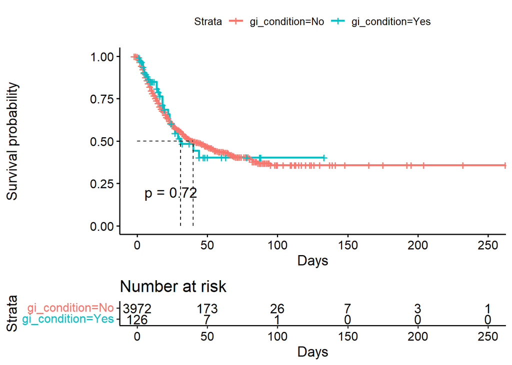

```
## Call: survfit(formula = Surv(censer_death, death_code) ~ gi_condition,
##     data = wave_clean)
##
##    67 observations deleted due to missingness
##                     n events median 0.95LCL 0.95UCL
## gi_condition=No  4009    890     40      35      51
## gi_condition=Yes  126     30     31      23      NA
```

**Interpret**: The effect of chronic GI condition on survival time was investigated using survival analysis. Patients with chronic GI condition had a median survival time of 31 days, whereas those without chronic GI condition had a median survival time of 40 days. However, the difference was not significant between the two survival plots (p=0.72).

## Other complications

```
##
## Call:
## glm(formula = septic_shock ~ gi_condition + sex + race_eth +
##     age_cat + obesity + cancer_factor + cva_comorbidity + wave,
##     family = binomial, data = wave_clean)
##
## Deviance Residuals:
##     Min       1Q   Median       3Q      Max
## -0.7690  -0.4927  -0.4337  -0.3422   2.7845
##
## Coefficients:
##                    Estimate Std. Error z value Pr(>|z|)
## (Intercept)        -2.58869    0.61235  -4.227 2.36e-05 ***
## gi_conditionYes     0.34256    0.29746   1.152   0.2495
## sexFemale          -0.28968    0.11856  -2.443   0.0146 *
## race_ethBlack      -0.15442    0.21155  -0.730   0.4654
## race_ethAsian       0.24211    0.16860   1.436   0.1510
## race_ethHispanic   -0.09021    0.15558  -0.580   0.5620
## race_ethOther      -0.19426    0.19814  -0.980   0.3269
## age_cat26 - 40     -0.54306    0.65849  -0.825   0.4095
## age_cat41 - 55      0.15081    0.61609   0.245   0.8066
## age_cat56 - 70      0.59158    0.60929   0.971   0.3316
## age_cat71 - 85      0.52203    0.61455   0.849   0.3956
## age_cat86+          0.12058    0.63753   0.189   0.8500
## obesityYes          0.30548    0.12514   2.441   0.0146 *
## cancer_factorYes    0.28946    0.23504   1.232   0.2181
## cva_comorbidityYes  0.03979    0.13156   0.302   0.7623
## wavewave2          -1.04761    0.42252  -2.479   0.0132 *
## ---
## Signif. codes:  0 '***' 0.001 '**' 0.01 '*' 0.05 '.' 0.1 ' ' 1
##
## (Dispersion parameter for binomial family taken to be 1)
##
##     Null deviance: 2356.3  on 3696  degrees of freedom
## Residual deviance: 2298.0  on 3681  degrees of freedom
##   (505 observations deleted due to missingness)
## AIC: 2330
##
## Number of Fisher Scoring iterations: 6
```

```
##
## Call:
## glm(formula = arrhythmias ~ gi_condition + sex + race_eth + age_cat +
##     obesity + cancer_factor + cva_comorbidity + wave, family = binomial,
##     data = wave_clean)
##
## Deviance Residuals:
##     Min       1Q   Median       3Q      Max
## -0.7958  -0.4670  -0.3668  -0.2319   3.0809
##
## Coefficients:
##                    Estimate Std. Error z value Pr(>|z|)
## (Intercept)         -3.6149     1.0229  -3.534 0.000409 ***
## gi_conditionYes      0.6067     0.3122   1.944 0.051940 .
## sexFemale           -0.5629     0.1369  -4.113 3.91e-05 ***
## race_ethBlack       -0.1935     0.2348  -0.824 0.409898
## race_ethAsian        0.2402     0.1814   1.324 0.185342
## race_ethHispanic    -0.3654     0.1811  -2.017 0.043653 *
## race_ethOther        0.1592     0.2004   0.794 0.427020
## age_cat26 - 40      -0.4952     1.1092  -0.446 0.655292
## age_cat41 - 55       0.3164     1.0358   0.305 0.760038
## age_cat56 - 70       1.3153     1.0217   1.287 0.197987
## age_cat71 - 85       1.6031     1.0243   1.565 0.117563
## age_cat86+           1.2513     1.0380   1.205 0.228031
## obesityYes           0.3480     0.1429   2.435 0.014908 *
## cancer_factorYes    -0.2637     0.2996  -0.880 0.378710
## cva_comorbidityYes   0.1773     0.1544   1.148 0.250823
## wavewave2           -0.9769     0.4633  -2.109 0.034985 *
## ---
## Signif. codes:  0 '***' 0.001 '**' 0.01 '*' 0.05 '.' 0.1 ' ' 1
##
## (Dispersion parameter for binomial family taken to be 1)
##
##     Null deviance: 2008.2  on 3696  degrees of freedom
## Residual deviance: 1890.2  on 3681  degrees of freedom
##   (505 observations deleted due to missingness)
## AIC: 1922.2
##
## Number of Fisher Scoring iterations: 6
```

```
##
## Call:
## glm(formula = mi ~ gi_condition + sex + race_eth + age_cat +
##     obesity + cancer_factor + cva_comorbidity + wave, family = binomial,
##     data = wave_clean)
##
## Deviance Residuals:
##     Min       1Q   Median       3Q      Max
## -0.5677  -0.2906  -0.2291  -0.1717   3.4877
##
## Coefficients:
##                    Estimate Std. Error z value Pr(>|z|)
## (Intercept)        -17.4064   560.8131  -0.031 0.975239
## gi_conditionYes      0.8504     0.4112   2.068 0.038614 *
## sexFemale           -0.7814     0.2213  -3.531 0.000414 ***
## race_ethBlack        0.2039     0.3420   0.596 0.551129
## race_ethAsian        0.2780     0.2864   0.971 0.331641
## race_ethHispanic    -0.1185     0.2840  -0.417 0.676456
## race_ethOther        0.2895     0.3154   0.918 0.358803
## age_cat26 - 40      12.1827   560.8135   0.022 0.982669
## age_cat41 - 55      13.3146   560.8131   0.024 0.981059
## age_cat56 - 70      13.5610   560.8131   0.024 0.980708
## age_cat71 - 85      13.9461   560.8131   0.025 0.980161
## age_cat86+          13.9919   560.8131   0.025 0.980095
## obesityYes           0.2393     0.2213   1.081 0.279501
## cancer_factorYes    -0.2557     0.4691  -0.545 0.585664
## cva_comorbidityYes   0.5808     0.2611   2.224 0.026118 *
## wavewave2           -0.9769     0.7234  -1.350 0.176902
## ---
## Signif. codes:  0 '***' 0.001 '**' 0.01 '*' 0.05 '.' 0.1 ' ' 1
##
## (Dispersion parameter for binomial family taken to be 1)
##
##     Null deviance: 1010.77  on 3696  degrees of freedom
## Residual deviance:  959.33  on 3681  degrees of freedom
##   (505 observations deleted due to missingness)
## AIC: 991.33
##
## Number of Fisher Scoring iterations: 16
```

```
##
## Call:
## glm(formula = hf1 ~ gi_condition + sex + race_eth + age_cat +
##     obesity + cancer_factor + cva_comorbidity + wave, family = binomial,
##     data = wave_clean)
##
## Deviance Residuals:
##     Min       1Q   Median       3Q      Max
## -0.6056  -0.3001  -0.2711  -0.2036   3.0295
##
## Coefficients:
##                    Estimate Std. Error z value Pr(>|z|)
## (Intercept)        -3.00627    0.75231  -3.996 6.44e-05 ***
## gi_conditionYes     0.39693    0.43568   0.911  0.36226
## sexFemale          -0.08252    0.18365  -0.449  0.65319
## race_ethBlack      -0.13534    0.30255  -0.447  0.65463
## race_ethAsian      -0.38054    0.28039  -1.357  0.17472
## race_ethHispanic   -0.29863    0.24222  -1.233  0.21762
## race_ethOther      -0.18408    0.28959  -0.636  0.52499
## age_cat26 - 40     -1.10539    0.85404  -1.294  0.19556
## age_cat41 - 55     -0.60914    0.76495  -0.796  0.42585
## age_cat56 - 70     -0.54042    0.75337  -0.717  0.47317
## age_cat71 - 85     -0.54833    0.76060  -0.721  0.47096
## age_cat86+         -0.49004    0.78468  -0.625  0.53229
## obesityYes         -0.16831    0.20662  -0.815  0.41530
## cancer_factorYes    0.68473    0.29978   2.284  0.02236 *
## cva_comorbidityYes  0.68693    0.23622   2.908  0.00364 **
## wavewave2           0.39118    0.34648   1.129  0.25889
## ---
## Signif. codes:  0 '***' 0.001 '**' 0.01 '*' 0.05 '.' 0.1 ' ' 1
##
## (Dispersion parameter for binomial family taken to be 1)
##
##     Null deviance: 1152.2  on 3696  degrees of freedom
## Residual deviance: 1123.1  on 3681  degrees of freedom
##   (505 observations deleted due to missingness)
## AIC: 1155.1
##
## Number of Fisher Scoring iterations: 6
```

```
##
## Call:
## glm(formula = vte1 ~ gi_condition + sex + race_eth + age_cat +
##     obesity + cancer_factor + cva_comorbidity + wave, family = binomial,
##     data = wave_clean)
##
## Deviance Residuals:
##     Min       1Q   Median       3Q      Max
## -0.7088  -0.3965  -0.3273  -0.2588   3.0130
##
## Coefficients:
##                    Estimate Std. Error z value Pr(>|z|)
## (Intercept)        -3.67786    1.02436  -3.590  0.00033 ***
## gi_conditionYes    -0.15883    0.43161  -0.368  0.71288
## sexFemale          -0.39609    0.14968  -2.646  0.00814 **
## race_ethBlack       0.58060    0.22215   2.614  0.00896 **
## race_ethAsian      -0.12304    0.22886  -0.538  0.59084
## race_ethHispanic   -0.20743    0.20028  -1.036  0.30035
## race_ethOther       0.08501    0.23017   0.369  0.71189
## age_cat26 - 40     -0.24693    1.09310  -0.226  0.82128
## age_cat41 - 55      0.71624    1.03065   0.695  0.48709
## age_cat56 - 70      1.40278    1.02168   1.373  0.16975
## age_cat71 - 85      1.32891    1.02658   1.294  0.19549
## age_cat86+          0.67726    1.05585   0.641  0.52124
## obesityYes          0.17127    0.15511   1.104  0.26954
## cancer_factorYes    0.49848    0.26009   1.917  0.05530 .
## cva_comorbidityYes -0.15466    0.16072  -0.962  0.33589
## wavewave2          -0.34040    0.37610  -0.905  0.36542
## ---
## Signif. codes:  0 '***' 0.001 '**' 0.01 '*' 0.05 '.' 0.1 ' ' 1
##
## (Dispersion parameter for binomial family taken to be 1)
##
##     Null deviance: 1684.7  on 3696  degrees of freedom
## Residual deviance: 1622.1  on 3681  degrees of freedom
##   (505 observations deleted due to missingness)
## AIC: 1654.1
##
## Number of Fisher Scoring iterations: 6
```

```
##
## Call:
## glm(formula = renal_replacement1 ~ gi_condition + sex + race_eth +
##     age_cat + obesity + cancer_factor + cva_comorbidity + wave,
##     family = binomial, data = wave_clean)
##
## Deviance Residuals:
##     Min       1Q   Median       3Q      Max
## -0.8562  -0.5075  -0.3813  -0.2632   2.8705
##
## Coefficients:
##                     Estimate Std. Error z value Pr(>|z|)
## (Intercept)        -17.03514  336.41841  -0.051 0.959615
## gi_conditionYes      0.25531    0.29516   0.865 0.387045
## sexFemale           -0.54121    0.12463  -4.343 1.41e-05 ***
## race_ethBlack        0.81472    0.20148   4.044 5.26e-05 ***
## race_ethAsian        0.63971    0.19113   3.347 0.000817 ***
## race_ethHispanic     0.55641    0.17239   3.228 0.001248 **
## race_ethOther       -0.05701    0.22927  -0.249 0.803635
## age_cat26 - 40      12.94307  336.41851   0.038 0.969310
## age_cat41 - 55      13.74635  336.41840   0.041 0.967407
## age_cat56 - 70      14.22887  336.41839   0.042 0.966263
## age_cat71 - 85      13.83284  336.41840   0.041 0.967202
## age_cat86+          12.93152  336.41849   0.038 0.969338
## obesityYes           0.29793    0.12546   2.375 0.017562 *
## cancer_factorYes    -0.13335    0.28392  -0.470 0.638585
## cva_comorbidityYes   0.87879    0.15142   5.803 6.50e-09 ***
## wavewave2           -0.24956    0.31393  -0.795 0.426643
## ---
## Signif. codes:  0 '***' 0.001 '**' 0.01 '*' 0.05 '.' 0.1 ' ' 1
##
## (Dispersion parameter for binomial family taken to be 1)
##
##     Null deviance: 2342.9  on 3696  degrees of freedom
## Residual deviance: 2168.6  on 3681  degrees of freedom
##   (505 observations deleted due to missingness)
## AIC: 2200.6
##
## Number of Fisher Scoring iterations: 15
```

[output not shown]